# Introuduction of Github and Loni PipeLine

## Learn about Version Control with Git

Git is a free and open source distributed version control system designed to handle everything from small to very large projects with speed and efficiency.

Git is a distributed version control system. In distributed systems, each developer has their own full-fledged repository on their computer. In most set-ups there’s an additional central repository on a server that is used for sharing. However, this is not a requirement; every developer can perform all important actions in their local repository: committing changes, viewing differences between revisions, switching branches, etc.

In Git, a file in your working directory can be in one of several states. The most basic distinction is between tracked and untracked. A file is tracked if it is already under version control; in this case, Git observes all changes in that file. If it is not saved in your Git repository, then it is treated as untracked.

Tracked files can be in one of the following three states:

*Unmodified or committed*

The file is in its last committed state and therefore has no local modifications.

*Modified*

The file has been changed since it was last committed.

*Staged*

The file was not only changed but also added to the staging area, meaning that the changes will be included in the next commit. Because a file can be staged partially, it’s entirely possible for it to be both staged and modified.

There are some tutorials link:

https://www.smashingmagazine.com/2011/07/modern-version-control-with-git-series/

https://guides.github.com/

## Use Version Control with Github Desktop

Before you authenticate to Github, you have to sign up for a new GitHub account.

After applying an account, you could load CBDA files in your own laptop.

**1st step : Download Github desktop**

Visit the GitHub Desktop download page:

https://desktop.github.com

**2nd step : Clone CBDA in your own laptop**

1. Open the Github Desktop, in the upper-left corner of your screen, select the GitHub Desktop menu.
2. Choose Preferences.

[figure not shown]

3. In the Preferences window, select Accounts.

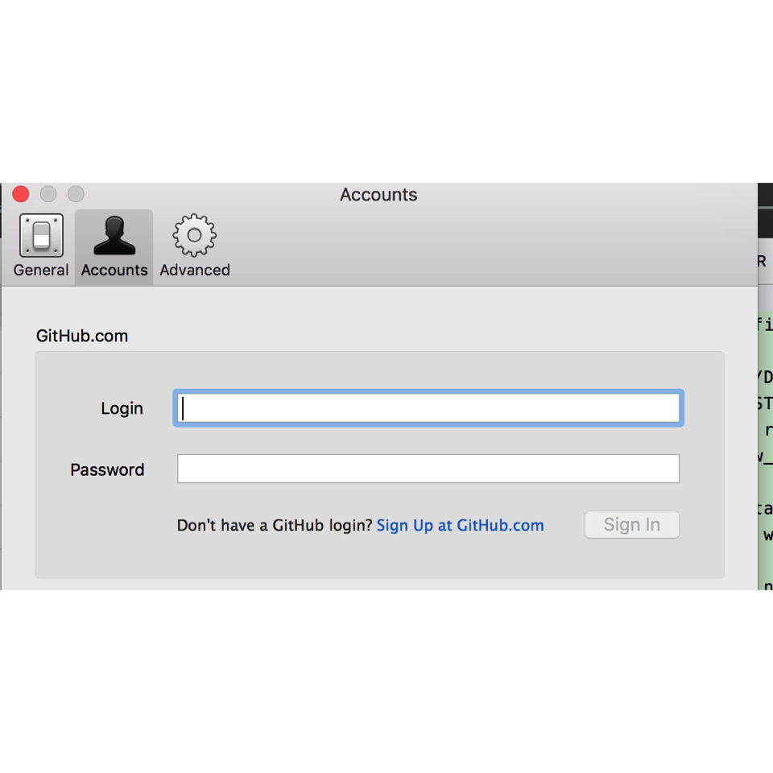

4. In the Accounts pane, type your GitHub.com credentials and click Sign In.
5. Open the link:

https://github.com/SOCR/CBDA

Click the gree button *Clone or download*, then click *Open in Desktop*.

[figure not shown]

6. In GitHub Desktop, after verifying the name and location on your hard drive where you’d like to clone the repository, click Clone

Then you have cloned the CBDA file in your own laptop.

**3rd step : Sync and make commits**

*About Sync*

If a team member has changed some files or add something new to the project, and you want to keep updated with the remote server. In the upper-right corner of the Desktop, click **Sync**.

As you make changes to your project locally, you can keep them up-to-date with your remote repository. In this project, a *remote* is the CBDA server.

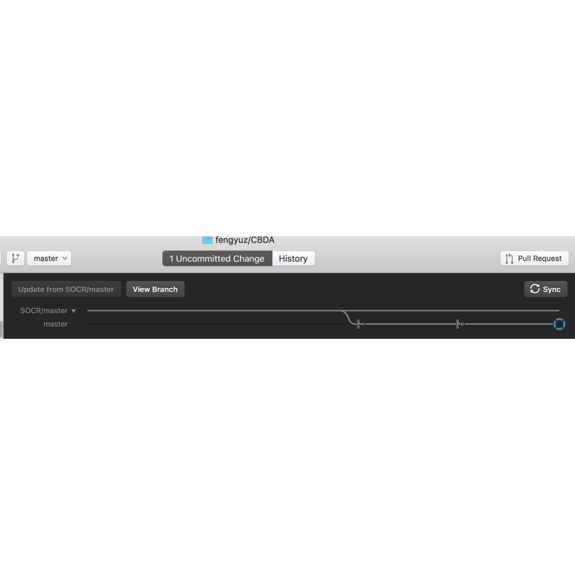

*About Commits*

When you want to create something or do some changes to the files in your project, you could push it to your project by creating *commits*, which briefly describes the changes.

As commits are pushed to your project on GitHub, you can keep your local copy of the project in sync with the remote repository.

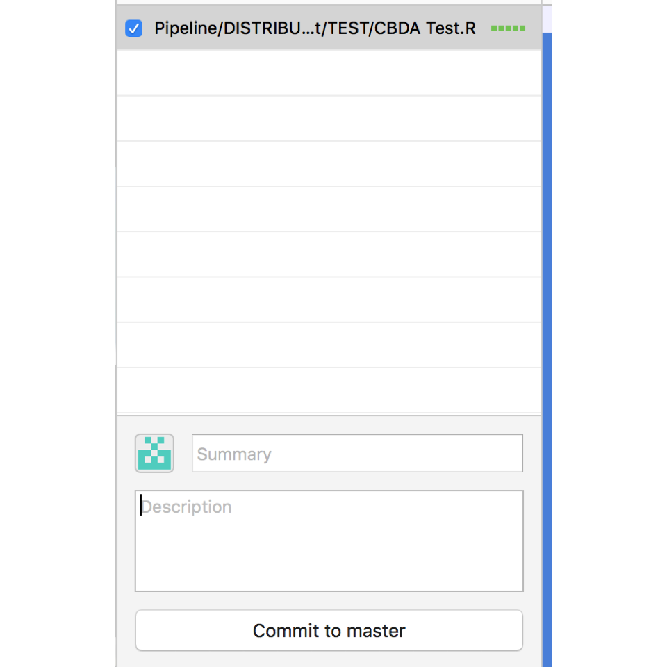

This is a tutorial about Contributing to Projects with Github Desktop:

https://help.github.com/desktop/guides/contributing/

## Learn about the LONI Pipeline

**1st step : Download the LONI Pipeline**

Visit the Pipeline download page:

http://pipeline.loni.usc.edu/products-services/pipeline-software/

**2nd step : Apply to a LONI Pipeline guest account**

Open the link: http://pipeline.loni.usc.edu/products-services/pws/.

Then click *Click here to launch the Pipeline Web Start* to download the JNLP file.

[figure not shown]

After download the Pipeline JNLP file, right click it and choose open with Java Web Start.

[figure not shown]

When the LONI pipeline is running, at the bottom right there is an icon and it says Not Connected. Click the button and select *Try it now*, then the button change green and it would say Connection.

[figure not shown]